# Bellabeat Fitness Data Analysis

Sahil Bhatia

January 7, 2025

# Introduction

Bellabeat is a health-focused company founded in 2013 that manufactures smart wellness products for women. Their products and app collect data on activity, stress, sleep, and health, empowering women to make informed decisions about their wellness. With its growing potential, Bellabeat aims to expand its presence in the smart device market. Since 2016, Bellabeat has marketed its products through digital channels like Instagram, Facebook, YouTube, Twitter, and Google Search.

# Business Task

Bellabeat’s goal is to analyze how users interact with non-Bellabeat smart devices. The insights will help inform strategies to improve Bellabeat’s marketing and customer engagement. The specific questions to address are:

1. What are the current trends in smart device usage?
2. How can these trends benefit Bellabeat customers?
3. How can these trends improve Bellabeat’s marketing strategy?

# Stakeholders

- **Urška Sršen**: Cofounder and Chief Creative Officer of Bellabeat.
- **Sando Mur**: Cofounder and mathematician; part of the executive team.
- **Bellabeat Marketing Analytics Team**: Responsible for analyzing and reporting data to guide marketing strategies.

# Bellabeat Products

- **Bellabeat App**: Tracks user activity, sleep, stress, menstrual cycle, and mindfulness habits. Connects to Bellabeat devices for personalized wellness insights.
- **Leaf**: A wellness tracker worn as a bracelet, necklace, or clip. Tracks activity, sleep, and stress.
- **Time**: A smart wellness watch that tracks activity, sleep, and stress with a classic timepiece design.
- **Spring**: A smart water bottle that monitors daily hydration levels and connects to the app.
- **Bellabeat Membership**: A subscription offering personalized guidance on health, nutrition, sleep, and mindfulness.

# Deliverables

This analysis will include:

1. **Business Task Summary**: A clear explanation of the task.
2. **Data Sources Description**: Details of the data used for analysis.
3. **Data Cleaning and Preparation**: Documentation of how the data was cleaned or transformed.
4. **Analysis Summary**: Key insights from the data.
5. **Visualizations and Findings**: Graphs, charts, or other visual representations supporting the analysis.
6. **Recommendations**: High-level suggestions based on the findings.

# Key Considerations

- Understand the stakeholders’ expectations and the problems they want to address.
- Focus on solving the business task and avoid unnecessary distractions.
- Collaborate with stakeholders and maintain clear communication throughout the process.
- Step back to see the broader context of the situation.

# Questions to Guide the Process

1. What challenges or questions do stakeholders need answers to?
2. How can the analysis help solve these problems or guide decision-making?

# Key Tasks

1. Define the business task.
2. Identify the key stakeholders and their expectations.

# Deliverable

Provide a concise and clear statement summarizing the business task and its objectives.

# Step 1: Ask

The main question is: **How can Bellabeat use insights from fitness tracking data to improve its marketing strategy?**

### Objectives:

1. Analyze fitness tracker usage data.
2. Identify key trends and user behaviors.
3. Provide actionable recommendations to promote Bellabeat products.

# Step 2: Prepare

## Data Source

For this analysis, I used the following public dataset: [**FitBit Fitness Tracker Data**](https://www.kaggle.com/datasets/arashnic/fitbit) (CC0: Public Domain, dataset made available through Mobius).

**Key Details:** - A total of **18 CSV files** were downloaded and stored properly for this analysis. - The dataset includes various metrics that provide insights into daily activity, sleep patterns, and health tracking.

## ROCCC Analysis

The ROCCC framework was applied to evaluate the dataset:

- **Reliable:** Low — The data was collected from users without demographic information, which might affect its reliability.
- **Originality:** Low — The data was collected from third-party Amazon Mechanical Turk users, limiting its originality.
- **Comprehensive:** High — The dataset contains a broad range of personal health metrics, enabling the answering of business questions.
- **Current:** Low — The data was collected between **03.12.2016–05.12.2016**, making it outdated for current trend analysis.
- **Cited:** High — The dataset source is well-documented and publicly available on Kaggle.

## Guiding Questions

### 1. **Where is your data stored?**

The data is stored on Kaggle, a popular platform for sharing datasets. It can be downloaded from the [FitBit Fitness Tracker Data](https://www.kaggle.com/datasets/arashnic/fitbit) page to local machines or cloud storage.

### 2. **How is the data organized?**

The data is organized in **wide format**, where: - Each column represents a specific feature (e.g., `steps`, `heart_rate`, `activity_level`). - Each row represents a time-series data entry (e.g., daily or minute-level data for a user).

### 3. **Are there issues with bias or credibility in this data?**

Yes, there are some concerns: - **Bias:** The dataset may be biased toward health-conscious individuals or Fitbit users, limiting its generalizability. - **Credibility:** While the data is from Fitbit users, it was collected through Amazon Mechanical Turk, which may affect data consistency.

**ROCCC Summary:** - Reliable: Low - Original: Low - Comprehensive: High - Current: Low - Cited: High

### 4. **How are you addressing licensing, privacy, security, and accessibility?**

- **Licensing:** The dataset is shared under the **CC0: Public Domain** license, meaning it can be freely used without restrictions.
- **Privacy:** The data does not contain personally identifiable information. Users provided their data anonymously with consent.
- **Security:** The dataset is securely stored locally or in encrypted cloud storage.
- **Accessibility:** The dataset is freely accessible on Kaggle, ensuring transparency and ease of use.

### 6. **How does it help you answer your question?**

This dataset provides detailed insights into user activity, sleep, and heart rate, which align closely with Bellabeat’s products and target market. By analyzing this data, trends in **smart device usage** can be identified, enabling Bellabeat to improve its products and marketing strategies.

### 7. **Are there any problems with the data?**

Yes, there are potential issues: - **Missing or incomplete data:** Some users might not have consistently worn their devices, leading to gaps. - **Bias:** The dataset represents only Fitbit users, which may not generalize to Bellabeat’s broader target audience. - **Outdated data:** The dataset is several years old and may not reflect current trends in device usage.

## Key Tasks

1. **Download and store the data appropriately.**
- All 18 CSV files were downloaded from Kaggle and stored in a structured folder hierarchy.
2. **Identify how the data is organized.**
- Initial exploration confirmed the dataset is organized in wide format.
3. **Sort and filter the data.**
- Unnecessary columns and irrelevant rows were identified and excluded.
4. **Determine the credibility of the data.**
- The dataset’s source and metadata were examined for reliability, completeness, and timeliness.

#### Install Packages

```r
install.packages("tidyverse")
install.packages("lubridate")
install.packages("dplyr")
```

```r
install.packages("ggplot2")
install.packages("tidyr")
install.packages("here")
install.packages("skimr")
install.packages("janitor")
```

#### Load Libraries

```r
library(tidyverse)
```

```r
library(lubridate)
library(dplyr)
library(ggplot2)
library(tidyr)
library(here)
library(skimr)
library(janitor)
daily_activity <- read_csv("Datasets/mturkfitbit_export_4.12.16-5.12.16/Fitabase Data 4.12.16-5.12.16/dailyActivity_merged.csv")
daily_calories <- read_csv("Datasets/mturkfitbit_export_4.12.16-5.12.16/Fitabase Data 4.12.16-5.12.16/dailyCalories_merged.csv")
daily_intensities <- read_csv("Datasets/mturkfitbit_export_4.12.16-5.12.16/Fitabase Data 4.12.16-5.12.16/dailyIntensities_merged.csv")
daily_steps <- read_csv("Datasets/mturkfitbit_export_4.12.16-5.12.16/Fitabase Data 4.12.16-5.12.16/dailySteps_merged.csv")
heartrate <- read_csv("Datasets/mturkfitbit_export_4.12.16-5.12.16/Fitabase Data 4.12.16-5.12.16/heartrate_seconds_merged.csv")
weight_log <- read_csv("Datasets/mturkfitbit_export_4.12.16-5.12.16/Fitabase Data 4.12.16-5.12.16/weightLogInfo_merged.csv")
sleep <- read_csv("Datasets/mturkfitbit_export_4.12.16-5.12.16/Fitabase Data 4.12.16-5.12.16/sleepDay_merged.csv")
head(daily_activity)
```

```
## # A tibble: 6 × 15
##           Id ActivityDate TotalSteps TotalDistance TrackerDistance
##        <dbl> <chr>             <dbl>         <dbl>           <dbl>
## 1 1503960366 4/12/2016         13162          8.5             8.5
## 2 1503960366 4/13/2016         10735          6.97            6.97
## 3 1503960366 4/14/2016         10460          6.74            6.74
## 4 1503960366 4/15/2016          9762          6.28            6.28
## 5 1503960366 4/16/2016         12669          8.16            8.16
## 6 1503960366 4/17/2016          9705          6.48            6.48
## # ℹ 10 more variables: LoggedActivitiesDistance <dbl>,
## #   VeryActiveDistance <dbl>, ModeratelyActiveDistance <dbl>,
## #   LightActiveDistance <dbl>, SedentaryActiveDistance <dbl>,
## #   VeryActiveMinutes <dbl>, FairlyActiveMinutes <dbl>,
## #   LightlyActiveMinutes <dbl>, SedentaryMinutes <dbl>, Calories <dbl>
```

```r
colnames(daily_activity)
```

```
##  [1] "Id"                       "ActivityDate"
##  [3] "TotalSteps"               "TotalDistance"
##  [5] "TrackerDistance"          "LoggedActivitiesDistance"
##  [7] "VeryActiveDistance"       "ModeratelyActiveDistance"
##  [9] "LightActiveDistance"      "SedentaryActiveDistance"
## [11] "VeryActiveMinutes"        "FairlyActiveMinutes"
## [13] "LightlyActiveMinutes"     "SedentaryMinutes"
## [15] "Calories"
```

```r
str(daily_activity)
```

```
## spc_tbl_ [940 × 15] (S3: spec_tbl_df/tbl_df/tbl/data.frame)
##  $ Id                      : num [1:940] 1.5e+09 1.5e+09 1.5e+09 1.5e+09 1.5e+09 ...
##  $ ActivityDate            : chr [1:940] "4/12/2016" "4/13/2016" "4/14/2016" "4/15/2016" ...
##  $ TotalSteps              : num [1:940] 13162 10735 10460 9762 12669 ...
##  $ TotalDistance           : num [1:940] 8.5 6.97 6.74 6.28 8.16 ...
##  $ TrackerDistance         : num [1:940] 8.5 6.97 6.74 6.28 8.16 ...
##  $ LoggedActivitiesDistance: num [1:940] 0 0 0 0 0 0 0 0 0 0 ...
##  $ VeryActiveDistance      : num [1:940] 1.88 1.57 2.44 2.14 2.71 ...
##  $ ModeratelyActiveDistance: num [1:940] 0.55 0.69 0.4 1.26 0.41 ...
##  $ LightActiveDistance     : num [1:940] 6.06 4.71 3.91 2.83 5.04 ...
##  $ SedentaryActiveDistance : num [1:940] 0 0 0 0 0 0 0 0 0 0 ...
##  $ VeryActiveMinutes       : num [1:940] 25 21 30 29 36 38 42 50 28 19 ...
##  $ FairlyActiveMinutes     : num [1:940] 13 19 11 34 10 20 16 31 12 8 ...
##  $ LightlyActiveMinutes    : num [1:940] 328 217 181 209 221 164 233 264 205 211 ...
##  $ SedentaryMinutes        : num [1:940] 728 776 1218 726 773 ...
##  $ Calories                : num [1:940] 1985 1797 1776 1745 1863 ...
##  - attr(*, "spec")=
##   .. cols(
##   ..   Id = col_double(),
##   ..   ActivityDate = col_character(),
##   ..   TotalSteps = col_double(),
##   ..   TotalDistance = col_double(),
##   ..   TrackerDistance = col_double(),
##   ..   LoggedActivitiesDistance = col_double(),
##   ..   VeryActiveDistance = col_double(),
##   ..   ModeratelyActiveDistance = col_double(),
##   ..   LightActiveDistance = col_double(),
##   ..   SedentaryActiveDistance = col_double(),
##   ..   VeryActiveMinutes = col_double(),
##   ..   FairlyActiveMinutes = col_double(),
##   ..   LightlyActiveMinutes = col_double(),
##   ..   SedentaryMinutes = col_double(),
##   ..   Calories = col_double()
##   .. )
##  - attr(*, "problems")=<externalptr>
```

```r
glimpse(daily_activity)
```

```
## Rows: 940
## Columns: 15
## $ Id                       <dbl> 1503960366, 1503960366, 1503960366, 150396036…
## $ ActivityDate             <chr> "4/12/2016", "4/13/2016", "4/14/2016", "4/15/…
## $ TotalSteps               <dbl> 13162, 10735, 10460, 9762, 12669, 9705, 13019…
## $ TotalDistance            <dbl> 8.50, 6.97, 6.74, 6.28, 8.16, 6.48, 8.59, 9.8…
## $ TrackerDistance          <dbl> 8.50, 6.97, 6.74, 6.28, 8.16, 6.48, 8.59, 9.8…
## $ LoggedActivitiesDistance <dbl> 0, 0, 0, 0, 0, 0, 0, 0, 0, 0, 0, 0, 0, 0, 0, …
## $ VeryActiveDistance       <dbl> 1.88, 1.57, 2.44, 2.14, 2.71, 3.19, 3.25, 3.5…
## $ ModeratelyActiveDistance <dbl> 0.55, 0.69, 0.40, 1.26, 0.41, 0.78, 0.64, 1.3…
## $ LightActiveDistance      <dbl> 6.06, 4.71, 3.91, 2.83, 5.04, 2.51, 4.71, 5.0…
## $ SedentaryActiveDistance  <dbl> 0, 0, 0, 0, 0, 0, 0, 0, 0, 0, 0, 0, 0, 0, 0, …
## $ VeryActiveMinutes        <dbl> 25, 21, 30, 29, 36, 38, 42, 50, 28, 19, 66, 4…
## $ FairlyActiveMinutes      <dbl> 13, 19, 11, 34, 10, 20, 16, 31, 12, 8, 27, 21…
## $ LightlyActiveMinutes     <dbl> 328, 217, 181, 209, 221, 164, 233, 264, 205, …
## $ SedentaryMinutes         <dbl> 728, 776, 1218, 726, 773, 539, 1149, 775, 818…
## $ Calories                 <dbl> 1985, 1797, 1776, 1745, 1863, 1728, 1921, 203…
```

```r
head(daily_calories)
```

```
## # A tibble: 6 × 3
##           Id ActivityDay Calories
##        <dbl> <chr>          <dbl>
## 1 1503960366 4/12/2016       1985
## 2 1503960366 4/13/2016       1797
## 3 1503960366 4/14/2016       1776
## 4 1503960366 4/15/2016       1745
## 5 1503960366 4/16/2016       1863
## 6 1503960366 4/17/2016       1728
```

```r
colnames(daily_calories)
```

```
## [1] "Id"          "ActivityDay" "Calories"
```

```r
str(daily_calories)
```

```
## spc_tbl_ [940 × 3] (S3: spec_tbl_df/tbl_df/tbl/data.frame)
##  $ Id         : num [1:940] 1.5e+09 1.5e+09 1.5e+09 1.5e+09 1.5e+09 ...
##  $ ActivityDay: chr [1:940] "4/12/2016" "4/13/2016" "4/14/2016" "4/15/2016" ...
##  $ Calories   : num [1:940] 1985 1797 1776 1745 1863 ...
##  - attr(*, "spec")=
##   .. cols(
##   ..   Id = col_double(),
##   ..   ActivityDay = col_character(),
##   ..   Calories = col_double()
##   .. )
##  - attr(*, "problems")=<externalptr>
```

```r
glimpse(daily_calories)
```

```
## Rows: 940
## Columns: 3
## $ Id          <dbl> 1503960366, 1503960366, 1503960366, 1503960366, 1503960366…
## $ ActivityDay <chr> "4/12/2016", "4/13/2016", "4/14/2016", "4/15/2016", "4/16/…
## $ Calories    <dbl> 1985, 1797, 1776, 1745, 1863, 1728, 1921, 2035, 1786, 1775…
```

```r
head(daily_intensities)
```

```
## # A tibble: 6 × 10
##         Id ActivityDay SedentaryMinutes LightlyActiveMinutes FairlyActiveMinutes
##      <dbl> <chr>                  <dbl>                <dbl>               <dbl>
## 1   1.50e9 4/12/2016                728                  328                  13
## 2   1.50e9 4/13/2016                776                  217                  19
## 3   1.50e9 4/14/2016               1218                  181                  11
## 4   1.50e9 4/15/2016                726                  209                  34
## 5   1.50e9 4/16/2016                773                  221                  10
## 6   1.50e9 4/17/2016                539                  164                  20
## # ℹ 5 more variables: VeryActiveMinutes <dbl>, SedentaryActiveDistance <dbl>,
## #   LightActiveDistance <dbl>, ModeratelyActiveDistance <dbl>,
## #   VeryActiveDistance <dbl>
```

```r
colnames(daily_intensities)
```

```
##  [1] "Id"                       "ActivityDay"
##  [3] "SedentaryMinutes"         "LightlyActiveMinutes"
##  [5] "FairlyActiveMinutes"      "VeryActiveMinutes"
##  [7] "SedentaryActiveDistance"  "LightActiveDistance"
##  [9] "ModeratelyActiveDistance" "VeryActiveDistance"
```

```r
str(daily_intensities)
```

```
## spc_tbl_ [940 × 10] (S3: spec_tbl_df/tbl_df/tbl/data.frame)
##  $ Id                      : num [1:940] 1.5e+09 1.5e+09 1.5e+09 1.5e+09 1.5e+09 ...
##  $ ActivityDay             : chr [1:940] "4/12/2016" "4/13/2016" "4/14/2016" "4/15/2016" ...
##  $ SedentaryMinutes        : num [1:940] 728 776 1218 726 773 ...
##  $ LightlyActiveMinutes    : num [1:940] 328 217 181 209 221 164 233 264 205 211 ...
##  $ FairlyActiveMinutes     : num [1:940] 13 19 11 34 10 20 16 31 12 8 ...
##  $ VeryActiveMinutes       : num [1:940] 25 21 30 29 36 38 42 50 28 19 ...
##  $ SedentaryActiveDistance : num [1:940] 0 0 0 0 0 0 0 0 0 0 ...
##  $ LightActiveDistance     : num [1:940] 6.06 4.71 3.91 2.83 5.04 ...
##  $ ModeratelyActiveDistance: num [1:940] 0.55 0.69 0.4 1.26 0.41 ...
##  $ VeryActiveDistance      : num [1:940] 1.88 1.57 2.44 2.14 2.71 ...
##  - attr(*, "spec")=
##   .. cols(
##   ..   Id = col_double(),
##   ..   ActivityDay = col_character(),
##   ..   SedentaryMinutes = col_double(),
##   ..   LightlyActiveMinutes = col_double(),
##   ..   FairlyActiveMinutes = col_double(),
##   ..   VeryActiveMinutes = col_double(),
##   ..   SedentaryActiveDistance = col_double(),
##   ..   LightActiveDistance = col_double(),
##   ..   ModeratelyActiveDistance = col_double(),
##   ..   VeryActiveDistance = col_double()
##   .. )
##  - attr(*, "problems")=<externalptr>
```

```r
glimpse(daily_intensities)
```

```
## Rows: 940
## Columns: 10
## $ Id                       <dbl> 1503960366, 1503960366, 1503960366, 150396036…
## $ ActivityDay              <chr> "4/12/2016", "4/13/2016", "4/14/2016", "4/15/…
## $ SedentaryMinutes         <dbl> 728, 776, 1218, 726, 773, 539, 1149, 775, 818…
## $ LightlyActiveMinutes     <dbl> 328, 217, 181, 209, 221, 164, 233, 264, 205, …
## $ FairlyActiveMinutes      <dbl> 13, 19, 11, 34, 10, 20, 16, 31, 12, 8, 27, 21…
## $ VeryActiveMinutes        <dbl> 25, 21, 30, 29, 36, 38, 42, 50, 28, 19, 66, 4…
## $ SedentaryActiveDistance  <dbl> 0, 0, 0, 0, 0, 0, 0, 0, 0, 0, 0, 0, 0, 0, 0, …
## $ LightActiveDistance      <dbl> 6.06, 4.71, 3.91, 2.83, 5.04, 2.51, 4.71, 5.0…
## $ ModeratelyActiveDistance <dbl> 0.55, 0.69, 0.40, 1.26, 0.41, 0.78, 0.64, 1.3…
## $ VeryActiveDistance       <dbl> 1.88, 1.57, 2.44, 2.14, 2.71, 3.19, 3.25, 3.5…
```

```r
head(daily_steps)
```

```
## # A tibble: 6 × 3
##           Id ActivityDay StepTotal
##        <dbl> <chr>           <dbl>
## 1 1503960366 4/12/2016       13162
## 2 1503960366 4/13/2016       10735
## 3 1503960366 4/14/2016       10460
## 4 1503960366 4/15/2016        9762
## 5 1503960366 4/16/2016       12669
## 6 1503960366 4/17/2016        9705
```

```r
colnames(daily_steps)
```

```
## [1] "Id"          "ActivityDay" "StepTotal"
```

```r
str(daily_steps)
```

```
## spc_tbl_ [940 × 3] (S3: spec_tbl_df/tbl_df/tbl/data.frame)
##  $ Id         : num [1:940] 1.5e+09 1.5e+09 1.5e+09 1.5e+09 1.5e+09 ...
##  $ ActivityDay: chr [1:940] "4/12/2016" "4/13/2016" "4/14/2016" "4/15/2016" ...
##  $ StepTotal  : num [1:940] 13162 10735 10460 9762 12669 ...
##  - attr(*, "spec")=
##   .. cols(
##   ..   Id = col_double(),
##   ..   ActivityDay = col_character(),
##   ..   StepTotal = col_double()
##   .. )
##  - attr(*, "problems")=<externalptr>
```

```r
glimpse(daily_steps)
```

```
## Rows: 940
## Columns: 3
## $ Id          <dbl> 1503960366, 1503960366, 1503960366, 1503960366, 1503960366…
## $ ActivityDay <chr> "4/12/2016", "4/13/2016", "4/14/2016", "4/15/2016", "4/16/…
## $ StepTotal   <dbl> 13162, 10735, 10460, 9762, 12669, 9705, 13019, 15506, 1054…
```

```r
head(heartrate)
```

```
## # A tibble: 6 × 3
##           Id Time                 Value
##        <dbl> <chr>                <dbl>
## 1 2022484408 4/12/2016 7:21:00 AM    97
## 2 2022484408 4/12/2016 7:21:05 AM   102
## 3 2022484408 4/12/2016 7:21:10 AM   105
## 4 2022484408 4/12/2016 7:21:20 AM   103
## 5 2022484408 4/12/2016 7:21:25 AM   101
## 6 2022484408 4/12/2016 7:22:05 AM    95
```

```r
colnames(heartrate)
```

```
## [1] "Id"    "Time"  "Value"
```

```r
str(heartrate)
```

```
## spc_tbl_ [2,483,658 × 3] (S3: spec_tbl_df/tbl_df/tbl/data.frame)
##  $ Id   : num [1:2483658] 2.02e+09 2.02e+09 2.02e+09 2.02e+09 2.02e+09 ...
##  $ Time : chr [1:2483658] "4/12/2016 7:21:00 AM" "4/12/2016 7:21:05 AM" "4/12/2016 7:21:10 AM" "4/12/2016 7:21:20 AM" ...
##  $ Value: num [1:2483658] 97 102 105 103 101 95 91 93 94 93 ...
##  - attr(*, "spec")=
##   .. cols(
##   ..   Id = col_double(),
##   ..   Time = col_character(),
##   ..   Value = col_double()
##   .. )
##  - attr(*, "problems")=<externalptr>
```

```r
glimpse(heartrate)
```

```
## Rows: 2,483,658
## Columns: 3
## $ Id    <dbl> 2022484408, 2022484408, 2022484408, 2022484408, 2022484408, 2022…
## $ Time  <chr> "4/12/2016 7:21:00 AM", "4/12/2016 7:21:05 AM", "4/12/2016 7:21:…
## $ Value <dbl> 97, 102, 105, 103, 101, 95, 91, 93, 94, 93, 92, 89, 83, 61, 60, …
```

```r
head(weight_log)
```

```
## # A tibble: 6 × 8
##           Id Date       WeightKg WeightPounds   Fat   BMI IsManualReport   LogId
##        <dbl> <chr>         <dbl>        <dbl> <dbl> <dbl> <lgl>            <dbl>
## 1 1503960366 5/2/2016 …     52.6         116.    22  22.6 TRUE           1.46e12
## 2 1503960366 5/3/2016 …     52.6         116.    NA  22.6 TRUE           1.46e12
## 3 1927972279 4/13/2016…    134.          294.    NA  47.5 FALSE          1.46e12
## 4 2873212765 4/21/2016…     56.7         125.    NA  21.5 TRUE           1.46e12
## 5 2873212765 5/12/2016…     57.3         126.    NA  21.7 TRUE           1.46e12
## 6 4319703577 4/17/2016…     72.4         160.    25  27.5 TRUE           1.46e12
```

```r
colnames(weight_log)
```

```
## [1] "Id"             "Date"           "WeightKg"       "WeightPounds"
## [5] "Fat"            "BMI"            "IsManualReport" "LogId"
```

```r
str(weight_log)
```

```
## spc_tbl_ [67 × 8] (S3: spec_tbl_df/tbl_df/tbl/data.frame)
##  $ Id            : num [1:67] 1.50e+09 1.50e+09 1.93e+09 2.87e+09 2.87e+09 ...
##  $ Date          : chr [1:67] "5/2/2016 11:59:59 PM" "5/3/2016 11:59:59 PM" "4/13/2016 1:08:52 AM" "4/21/2016 11:59:59 PM" ...
##  $ WeightKg      : num [1:67] 52.6 52.6 133.5 56.7 57.3 ...
##  $ WeightPounds  : num [1:67] 116 116 294 125 126 ...
##  $ Fat           : num [1:67] 22 NA NA NA NA 25 NA NA NA NA ...
##  $ BMI           : num [1:67] 22.6 22.6 47.5 21.5 21.7 ...
##  $ IsManualReport: logi [1:67] TRUE TRUE FALSE TRUE TRUE TRUE ...
##  $ LogId         : num [1:67] 1.46e+12 1.46e+12 1.46e+12 1.46e+12 1.46e+12 ...
##  - attr(*, "spec")=
##   .. cols(
##   ..   Id = col_double(),
##   ..   Date = col_character(),
##   ..   WeightKg = col_double(),
##   ..   WeightPounds = col_double(),
##   ..   Fat = col_double(),
##   ..   BMI = col_double(),
##   ..   IsManualReport = col_logical(),
##   ..   LogId = col_double()
##   .. )
##  - attr(*, "problems")=<externalptr>
```

```r
glimpse(weight_log)
```

```
## Rows: 67
## Columns: 8
## $ Id             <dbl> 1503960366, 1503960366, 1927972279, 2873212765, 2873212…
## $ Date           <chr> "5/2/2016 11:59:59 PM", "5/3/2016 11:59:59 PM", "4/13/2…
## $ WeightKg       <dbl> 52.6, 52.6, 133.5, 56.7, 57.3, 72.4, 72.3, 69.7, 70.3, …
## $ WeightPounds   <dbl> 115.9631, 115.9631, 294.3171, 125.0021, 126.3249, 159.6…
## $ Fat            <dbl> 22, NA, NA, NA, NA, 25, NA, NA, NA, NA, NA, NA, NA, NA,…
## $ BMI            <dbl> 22.65, 22.65, 47.54, 21.45, 21.69, 27.45, 27.38, 27.25,…
## $ IsManualReport <lgl> TRUE, TRUE, FALSE, TRUE, TRUE, TRUE, TRUE, TRUE, TRUE, …
## $ LogId          <dbl> 1.462234e+12, 1.462320e+12, 1.460510e+12, 1.461283e+12,…
```

```r
head(sleep)
```

```
## # A tibble: 6 × 5
##           Id SleepDay        TotalSleepRecords TotalMinutesAsleep TotalTimeInBed
##        <dbl> <chr>                       <dbl>              <dbl>          <dbl>
## 1 1503960366 4/12/2016 12:0…                 1                327            346
## 2 1503960366 4/13/2016 12:0…                 2                384            407
## 3 1503960366 4/15/2016 12:0…                 1                412            442
## 4 1503960366 4/16/2016 12:0…                 2                340            367
## 5 1503960366 4/17/2016 12:0…                 1                700            712
## 6 1503960366 4/19/2016 12:0…                 1                304            320
```

```r
colnames(sleep)
```

```
## [1] "Id"                 "SleepDay"           "TotalSleepRecords"
## [4] "TotalMinutesAsleep" "TotalTimeInBed"
```

```r
str(sleep)
```

```
## spc_tbl_ [413 × 5] (S3: spec_tbl_df/tbl_df/tbl/data.frame)
##  $ Id                : num [1:413] 1.5e+09 1.5e+09 1.5e+09 1.5e+09 1.5e+09 ...
##  $ SleepDay          : chr [1:413] "4/12/2016 12:00:00 AM" "4/13/2016 12:00:00 AM" "4/15/2016 12:00:00 AM" "4/16/2016 12:00:00 AM" ...
##  $ TotalSleepRecords : num [1:413] 1 2 1 2 1 1 1 1 1 1 ...
##  $ TotalMinutesAsleep: num [1:413] 327 384 412 340 700 304 360 325 361 430 ...
##  $ TotalTimeInBed    : num [1:413] 346 407 442 367 712 320 377 364 384 449 ...
##  - attr(*, "spec")=
##   .. cols(
##   ..   Id = col_double(),
##   ..   SleepDay = col_character(),
##   ..   TotalSleepRecords = col_double(),
##   ..   TotalMinutesAsleep = col_double(),
##   ..   TotalTimeInBed = col_double()
##   .. )
##  - attr(*, "problems")=<externalptr>
```

```r
glimpse(sleep)
```

```
## Rows: 413
## Columns: 5
## $ Id                 <dbl> 1503960366, 1503960366, 1503960366, 1503960366, 150…
## $ SleepDay           <chr> "4/12/2016 12:00:00 AM", "4/13/2016 12:00:00 AM", "…
## $ TotalSleepRecords  <dbl> 1, 2, 1, 2, 1, 1, 1, 1, 1, 1, 1, 1, 1, 1, 1, 1, 1, …
## $ TotalMinutesAsleep <dbl> 327, 384, 412, 340, 700, 304, 360, 325, 361, 430, 2…
## $ TotalTimeInBed     <dbl> 346, 407, 442, 367, 712, 320, 377, 364, 384, 449, 3…
```

## Step 3: Process

### Guiding Questions

- What tools are you choosing and why?
- Have you ensured your data’s integrity?
- What steps have you taken to ensure that your data is clean?
- How can you verify that your data is clean and ready to analyze?
- Have you documented your cleaning process so you can review and share those results?

### Key Tasks

1. Check the data for errors.
2. Choose your tools.
3. Transform the data so you can work with it effectively.
4. Document the cleaning process.

### Deliverable

Documentation of any cleaning or manipulation of data.

### Data Cleaning Process

```r
# Total missing values
cat("Missing values in daily_activity:", sum(is.na(daily_activity)), "\n")
```

```
## Missing values in daily_activity: 0
```

```r
cat("Missing values in daily_calories:", sum(is.na(daily_calories)), "\n")
```

```
## Missing values in daily_calories: 0
```

```r
cat("Missing values in daily_intensities:", sum(is.na(daily_intensities)), "\n")
```

```
## Missing values in daily_intensities: 0
```

```r
cat("Missing values in daily_steps:", sum(is.na(daily_steps)), "\n")
```

```
## Missing values in daily_steps: 0
```

```r
cat("Missing values in heartrate:", sum(is.na(heartrate)), "\n")
```

```
## Missing values in heartrate: 0
```

```r
cat("Missing values in weight_log:", sum(is.na(weight_log)), "\n")
```

```
## Missing values in weight_log: 65
```

```r
cat("Missing values in sleep:", sum(is.na(sleep)), "\n")
```

```
## Missing values in sleep: 0
```

```r
# Check for empty rows
cat("Empty rows in daily_activity:", sum(rowSums(is.na(daily_activity)) == ncol(daily_activity)), "\n")
```

```
## Empty rows in daily_activity: 0
```

```r
cat("Empty rows in daily_calories:", sum(rowSums(is.na(daily_calories)) == ncol(daily_calories)), "\n")
```

```
## Empty rows in daily_calories: 0
```

```r
cat("Empty rows in daily_intensities:", sum(rowSums(is.na(daily_intensities)) == ncol(daily_intensities)), "\n")
```

```
## Empty rows in daily_intensities: 0
```

```r
cat("Empty rows in daily_steps:", sum(rowSums(is.na(daily_steps)) == ncol(daily_steps)), "\n")
```

```
## Empty rows in daily_steps: 0
```

```r
cat("Empty rows in heartrate:", sum(rowSums(is.na(heartrate)) == ncol(heartrate)), "\n")
```

```
## Empty rows in heartrate: 0
```

```r
cat("Empty rows in weight_log:", sum(rowSums(is.na(weight_log)) == ncol(weight_log)), "\n")
```

```
## Empty rows in weight_log: 0
```

```r
cat("Empty rows in sleep:", sum(rowSums(is.na(sleep)) == ncol(sleep)), "\n")
```

```
## Empty rows in sleep: 0
```

```r
# Check for empty columns
cat("Empty columns in daily_activity:", sum(colSums(is.na(daily_activity)) == nrow(daily_activity)), "\n")
```

```
## Empty columns in daily_activity: 0
```

```r
cat("Empty columns in daily_calories:", sum(colSums(is.na(daily_calories)) == nrow(daily_calories)), "\n")
```

```
## Empty columns in daily_calories: 0
```

```r
cat("Empty columns in daily_intensities:", sum(colSums(is.na(daily_intensities)) == nrow(daily_intensities)), "\n")
```

```
## Empty columns in daily_intensities: 0
```

```r
cat("Empty columns in daily_steps:", sum(colSums(is.na(daily_steps)) == nrow(daily_steps)), "\n")
```

```
## Empty columns in daily_steps: 0
```

```r
cat("Empty columns in heartrate:", sum(colSums(is.na(heartrate)) == nrow(heartrate)), "\n")
```

```
## Empty columns in heartrate: 0
```

```r
cat("Empty columns in weight_log:", sum(colSums(is.na(weight_log)) == nrow(weight_log)), "\n")
```

```
## Empty columns in weight_log: 0
```

```r
cat("Empty columns in sleep:", sum(colSums(is.na(sleep)) == nrow(sleep)), "\n")
```

```
## Empty columns in sleep: 0
```

```r
# Calculate the proportion of missing values in each column
# missing_proportion <- colSums(is.na(weight_log)) / nrow(weight_log)
#
# # Drop columns where the proportion of missing values is greater than 50%
# weight_log <- weight_log[, missing_proportion <= 0.5]
```

```r
# Check for duplicates
cat("Number of duplicate rows in daily_activity before removal:", nrow(daily_activity[duplicated(daily_activity),]), "\n")
```

```
## Number of duplicate rows in daily_activity before removal: 0
```

```r
cat("Number of duplicate rows in daily_calories before removal:", nrow(daily_calories[duplicated(daily_calories),]), "\n")
```

```
## Number of duplicate rows in daily_calories before removal: 0
```

```r
cat("Number of duplicate rows in daily_intensities before removal:", nrow(daily_intensities[duplicated(daily_intensities),]), "\n")
```

```
## Number of duplicate rows in daily_intensities before removal: 0
```

```r
cat("Number of duplicate rows in daily_steps before removal:", nrow(daily_steps[duplicated(daily_steps),]), "\n")
```

```
## Number of duplicate rows in daily_steps before removal: 0
```

```r
cat("Number of duplicate rows in heartrate before removal:", nrow(heartrate[duplicated(heartrate),]), "\n")
```

```
## Number of duplicate rows in heartrate before removal: 0
```

```r
cat("Number of duplicate rows in weight_log before removal:", nrow(weight_log[duplicated(weight_log),]), "\n")
```

```
## Number of duplicate rows in weight_log before removal: 0
```

```r
cat("Number of duplicate rows in sleep before removal:", nrow(sleep[duplicated(sleep),]), "\n")
```

```
## Number of duplicate rows in sleep before removal: 3
```

```r
# Remove duplicates
daily_activity <- daily_activity[!duplicated(daily_activity),]
daily_calories <- daily_calories[!duplicated(daily_calories),]
daily_intensities <- daily_intensities[!duplicated(daily_intensities),]
daily_steps <- daily_steps[!duplicated(daily_steps),]
heartrate <- heartrate[!duplicated(heartrate),]
weight_log <- weight_log[!duplicated(weight_log),]
sleep <- sleep[!duplicated(sleep),]

# Confirm duplicates removed
cat("Number of duplicate rows in sleep after removal:", nrow(sleep[duplicated(sleep),]), "\n")
```

```
## Number of duplicate rows in sleep after removal: 0
```

```r
# Convert character columns to date
daily_activity$ActivityDate <- as.Date(daily_activity$ActivityDate, format = "%m/%d/%Y")
daily_calories$ActivityDay <- as.Date(daily_calories$ActivityDay, format = "%m/%d/%Y")
daily_intensities$ActivityDay <- as.Date(daily_intensities$ActivityDay, format = "%m/%d/%Y")
daily_steps$ActivityDay <- as.Date(daily_steps$ActivityDay, format = "%m/%d/%Y")
heartrate$Time <- as.Date(heartrate$Time, format = "%m/%d/%Y")
weight_log$Date <- as.Date(weight_log$Date, format = "%m/%d/%Y")
sleep$SleepDay <- as.Date(sleep$SleepDay, format = "%m/%d/%Y")
```

```r
# Cleaning column names
daily_activity <- daily_activity %>% clean_names()
daily_calories <- daily_calories %>% clean_names()
daily_intensities <- daily_intensities %>% clean_names()
daily_steps <- daily_steps %>% clean_names()
heartrate <- heartrate %>% clean_names()
weight_log <- weight_log %>% clean_names()
sleep <- sleep %>% clean_names()
```

```r
# View updated column names
colnames(daily_activity)
```

```
##  [1] "id"                         "activity_date"
##  [3] "total_steps"                "total_distance"
##  [5] "tracker_distance"           "logged_activities_distance"
##  [7] "very_active_distance"       "moderately_active_distance"
##  [9] "light_active_distance"      "sedentary_active_distance"
## [11] "very_active_minutes"        "fairly_active_minutes"
## [13] "lightly_active_minutes"     "sedentary_minutes"
## [15] "calories"
```

```r
colnames(daily_calories)
```

```
## [1] "id"           "activity_day" "calories"
```

```r
colnames(daily_intensities)
```

```
##  [1] "id"                         "activity_day"
##  [3] "sedentary_minutes"          "lightly_active_minutes"
##  [5] "fairly_active_minutes"      "very_active_minutes"
##  [7] "sedentary_active_distance"  "light_active_distance"
##  [9] "moderately_active_distance" "very_active_distance"
```

```r
colnames(daily_steps)
```

```
## [1] "id"           "activity_day" "step_total"
```

```r
colnames(heartrate)
```

```
## [1] "id"    "time"  "value"
```

```r
colnames(sleep)
```

```
## [1] "id"                   "sleep_day"            "total_sleep_records"
## [4] "total_minutes_asleep" "total_time_in_bed"
```

```r
# Summarize key metrics
daily_activity %>%
  summarise(participants = n_distinct(id))
```

```
## # A tibble: 1 × 1
##   participants
##          <int>
## 1           33
```

```r
daily_calories %>%
  summarise(participants = n_distinct(id))
```

```
## # A tibble: 1 × 1
##   participants
##          <int>
## 1           33
```

```r
daily_intensities %>%
  summarise(participants = n_distinct(id))
```

```
## # A tibble: 1 × 1
##   participants
##          <int>
## 1           33
```

```r
daily_steps %>%
  summarise(participants = n_distinct(id))
```

```
## # A tibble: 1 × 1
##   participants
##          <int>
## 1           33
```

```r
heartrate %>%
  summarise(participants = n_distinct(id))
```

```
## # A tibble: 1 × 1
##   participants
##          <int>
## 1           14
```

```r
weight_log %>%
  summarise(participants = n_distinct(id))
```

```
## # A tibble: 1 × 1
##   participants
##          <int>
## 1            8
```

```r
sleep %>%
  summarise(participants = n_distinct(id))
```

```
## # A tibble: 1 × 1
##   participants
##          <int>
## 1           24
```

```r
# Key descriptive statistics
daily_activity %>%
  select(total_steps, total_distance, sedentary_minutes, calories) %>%
  summary()
```

```
##   total_steps    total_distance   sedentary_minutes    calories
##  Min.   :    0   Min.   : 0.000   Min.   :   0.0    Min.   :   0
##  1st Qu.: 3790   1st Qu.: 2.620   1st Qu.: 729.8    1st Qu.:1828
##  Median : 7406   Median : 5.245   Median :1057.5    Median :2134
##  Mean   : 7638   Mean   : 5.490   Mean   : 991.2    Mean   :2304
##  3rd Qu.:10727   3rd Qu.: 7.713   3rd Qu.:1229.5    3rd Qu.:2793
##  Max.   :36019   Max.   :28.030   Max.   :1440.0    Max.   :4900
```

```r
daily_intensities %>%
  select(very_active_minutes, lightly_active_minutes, fairly_active_minutes, sedentary_minutes) %>%
  summary()
```

```
##  very_active_minutes lightly_active_minutes fairly_active_minutes
##  Min.   :  0.00      Min.   :  0.0          Min.   :  0.00
##  1st Qu.:  0.00      1st Qu.:127.0          1st Qu.:  0.00
##  Median :  4.00      Median :199.0          Median :  6.00
##  Mean   : 21.16      Mean   :192.8          Mean   : 13.56
##  3rd Qu.: 32.00      3rd Qu.:264.0          3rd Qu.: 19.00
##  Max.   :210.00      Max.   :518.0          Max.   :143.00
##  sedentary_minutes
##  Min.   :   0.0
##  1st Qu.: 729.8
##  Median :1057.5
##  Mean   : 991.2
##  3rd Qu.:1229.5
##  Max.   :1440.0
```

```r
daily_calories %>%
  select(calories) %>%
  summary()
```

```
##     calories
##  Min.   :   0
##  1st Qu.:1828
##  Median :2134
##  Mean   :2304
##  3rd Qu.:2793
##  Max.   :4900
```

```r
sleep %>%
  select(total_sleep_records, total_minutes_asleep, total_time_in_bed) %>%
  summary()
```

```
##  total_sleep_records total_minutes_asleep total_time_in_bed
##  Min.   :1.00        Min.   : 58.0        Min.   : 61.0
##  1st Qu.:1.00        1st Qu.:361.0        1st Qu.:403.8
##  Median :1.00        Median :432.5        Median :463.0
##  Mean   :1.12        Mean   :419.2        Mean   :458.5
##  3rd Qu.:1.00        3rd Qu.:490.0        3rd Qu.:526.0
##  Max.   :3.00        Max.   :796.0        Max.   :961.0
```

```r
weight_log %>%
  select(weight_kg, bmi) %>%
  summary()
```

```
##    weight_kg           bmi
##  Min.   : 52.60   Min.   :21.45
##  1st Qu.: 61.40   1st Qu.:23.96
##  Median : 62.50   Median :24.39
##  Mean   : 72.04   Mean   :25.19
##  3rd Qu.: 85.05   3rd Qu.:25.56
##  Max.   :133.50   Max.   :47.54
```

```r
colnames(daily_activity)
```

```
##  [1] "id"                         "activity_date"
##  [3] "total_steps"                "total_distance"
##  [5] "tracker_distance"           "logged_activities_distance"
##  [7] "very_active_distance"       "moderately_active_distance"
##  [9] "light_active_distance"      "sedentary_active_distance"
## [11] "very_active_minutes"        "fairly_active_minutes"
## [13] "lightly_active_minutes"     "sedentary_minutes"
## [15] "calories"
```

```r
days <- format(daily_activity$activity_date, "%A")
daily_activity <- cbind(daily_activity, days)
```

### Key findings from this analysis :

- The average sedentary time is too high (more than 16 hours). And definitely needs to be reduced with a good marketing strategy.
- The majority of the participants are lightly active. With a high sedentary time.
- Participants sleep 1 time for an average of 7 hours.
- Average total steps per day (which is 7638) is a little bit less than recommended by the CDC. According to the CDC research, taking 8,000 steps per day was associated with a 51% lower risk for all-cause mortality (or death from all causes). And taking 12,000 steps per day was associated with a 65% lower risk compared with taking 4,000 steps.

## Step-4 Analyze

Now that your data is stored appropriately and has been prepared for analysis, start putting it to work. Use the following Case Study Roadmap as a guide:

### Guiding Questions

- How should you organize your data to perform analysis on it?
- Has your data been properly formatted?
- What surprises did you discover in the data?
- What trends or relationships did you find in the data?
- How will these insights help answer your business questions?

### Key Tasks

1. Aggregate your data so it’s useful and accessible.
2. Organize and format your data.
3. Perform calculations.
4. Identify trends and relationships.

### Deliverable

A summary of your analysis.

### Merging some data :¶

With the data cleaned and prepared, the next step is to integrate the three datasets into a single unified table.We merge the datasets to create a unified table that combines the key information from daily_activity, daily_steps, and daily_sleep. This integration enables a comprehensive analysis by linking activity, step count, and sleep data for each user on a specific date. By merging these datasets, we can identify patterns, correlations, and trends across multiple aspects of users’ behavior, which would not be possible if the data remained fragmented.

First, the daily_activity and daily_steps datasets are merged using the id and their respective date columns (activity_date and activity_day)..

Take a look :

```r
activity_steps_merged <- merge(daily_activity, daily_steps,
                               by.x = c("id", "activity_date"),
                               by.y = c("id", "activity_day"),
                               all = TRUE)
```

Next, the resulting merged dataset is combined with the daily_sleep dataset using the id and date columns (activity_date and sleep_day). This step integrates all three datasets into a unified table for analysis.

```r
merged_data <- merge(activity_steps_merged, sleep,
                     by.x = c("id", "activity_date"),
                     by.y = c("id", "sleep_day"),
                     all = TRUE)
```

- What’s the relationship between steps taken in a day and sedentary minutes?
- How could this help inform the customer segments that we can market to?
- E.g. position this more as a way to get started in walking more?
- Or to measure steps that you’re already taking?

## Step 5: Share

### Guiding questions

- **Were you able to answer the business questions?**
- **What story does your data tell?**
- **How do your findings relate to your original question?**
- **Who is your audience? What is the best way to communicate with them?**
- **Can data visualization help you share your findings?**
- **Is your presentation accessible to your audience?**

### Key tasks

1. Determine the best way to share your findings.
2. Create effective data visualizations.
3. Present your findings.
4. Ensure your work is accessible.

### Deliverable

Supporting visualizations and key findings.

### Follow these steps:

1. Take out a piece of paper and a pen and sketch some ideas for how you will visualize the data.
2. Once you choose a visual form, open your tool of choice to create your visualization. Use a presentation software, such as PowerPoint or Google Slides; your spreadsheet program; Tableau; or R.
3. Create your data visualization, remembering that contrast should be used to draw your audience’s attention to the most important insights. Use artistic principles including size, color, and shape.
4. Ensure clear meaning through the proper use of common elements, such as headlines, subtitles, and labels.
5. Refine your data visualization by applying deep attention to detail.

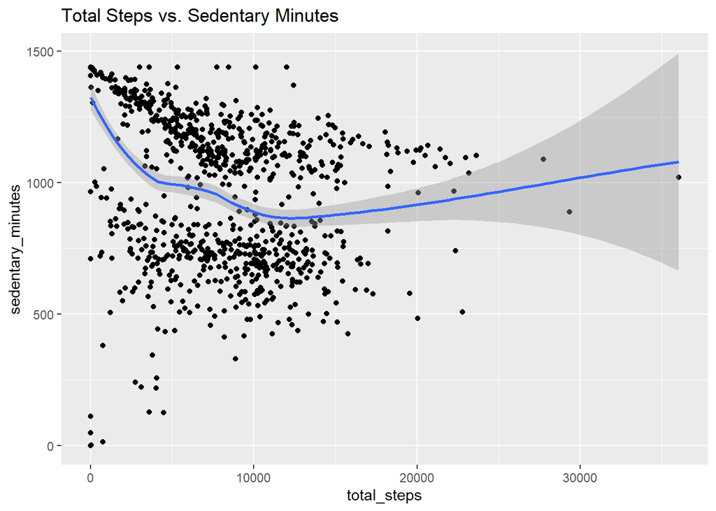

```r
ggplot(data = daily_activity, aes(x = total_steps, y = sedentary_minutes)) +
  geom_point() +
  geom_smooth() +
  labs(title = "Total Steps vs. Sedentary Minutes")
```

- What’s the relationship between minutes asleep and time in bed?
- You might expect it to be almost completely linear - are there any unexpected trends?
- The data shows a negative relationship between Steps and Sedentary time. This means that the more time someone spends sitting, the fewer steps they take during the day. The company should focus more on marketing to people with high Sedentary time and encourage them to start walking more and track their steps.

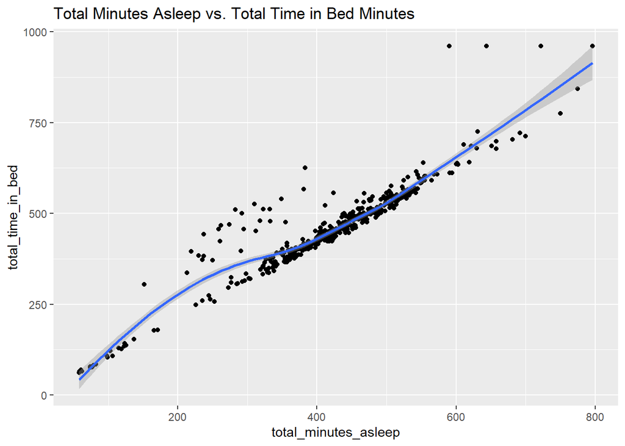

```r
ggplot(data = sleep, aes(x = total_minutes_asleep, y = total_time_in_bed)) +
  geom_point() +
  geom_smooth() +
  labs(title = "Total Minutes Asleep vs. Total Time in Bed Minutes")
```

- What could these trends tell you about how to help market this product? Or areas where you might want to explore further?
- There is also a strong connection between Minutes Asleep and Time in Bed, with a nearly straight-line trend. To help users sleep better, the company could send reminders to go to sleep.

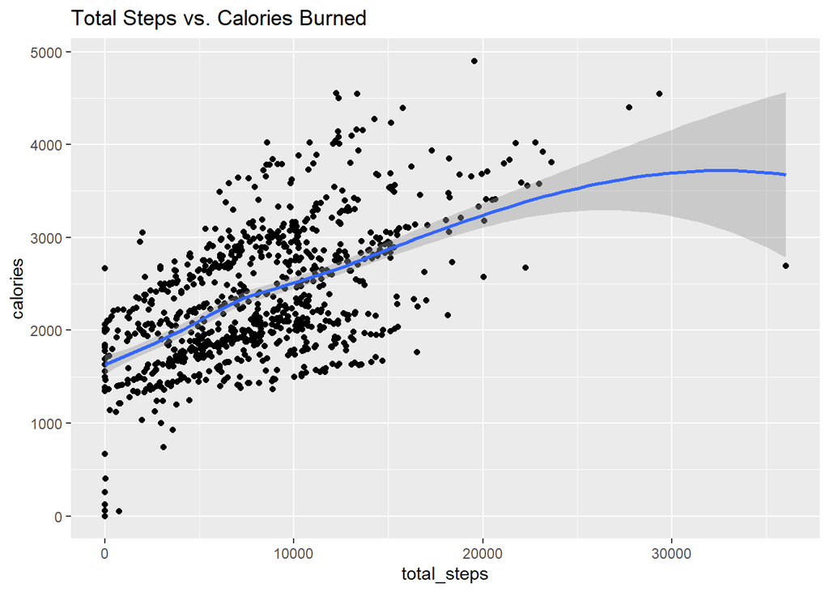

```r
ggplot(data = daily_activity, aes(x = total_steps, y = calories)) +
  geom_point() +
  geom_smooth() +
  labs(title = "Total Steps vs. Calories Burned")
```

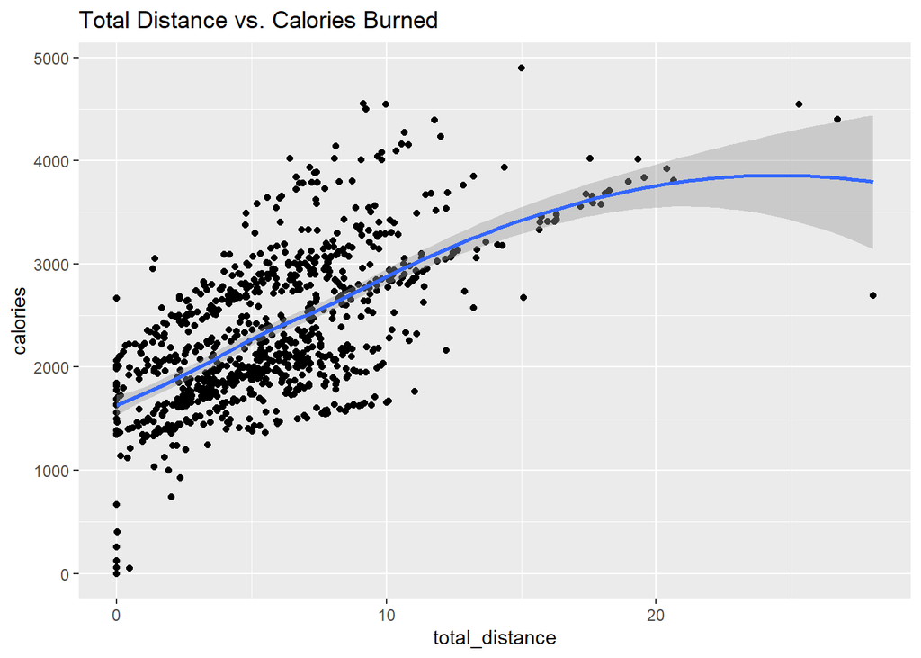

```r
ggplot(data = daily_activity, aes(x = total_distance, y = calories)) +
  geom_point() +
  geom_smooth() +
  labs(title = "Total Distance vs. Calories Burned")
```

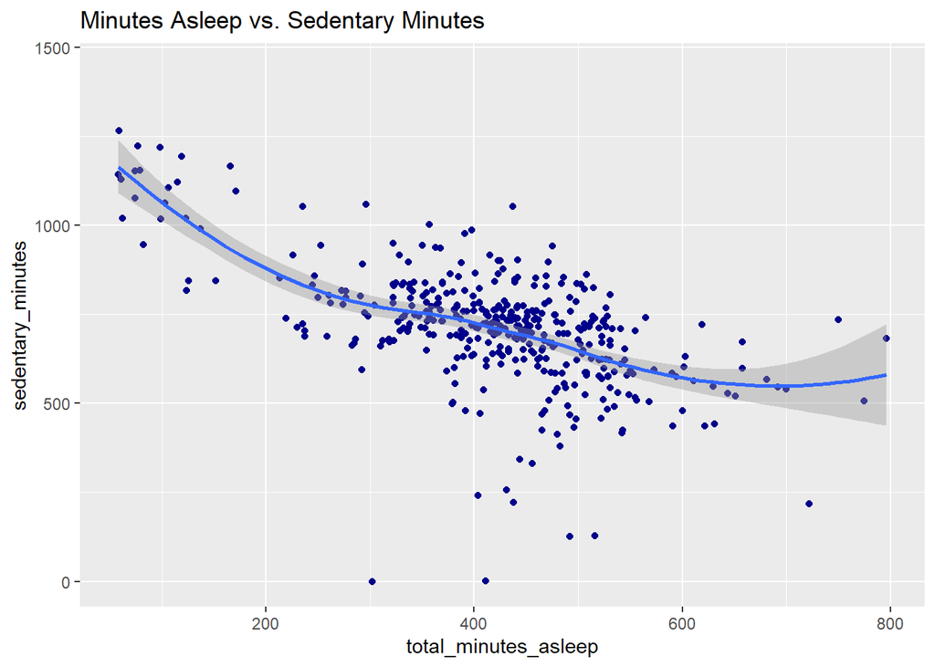

```r
ggplot(data = merged_data, aes(x = total_minutes_asleep, y = sedentary_minutes)) +
  geom_point(color = 'darkblue') +
  geom_smooth() +
  labs(title = "Minutes Asleep vs. Sedentary Minutes")
```

- There is a clear negative relationship between Sedentary Minutes and Sleep Time.
- Suggestion: To help users improve their sleep, the Bellabeat app could recommend reducing sedentary time.
- However, it’s important to gather more supporting data, as correlation does not imply causation.

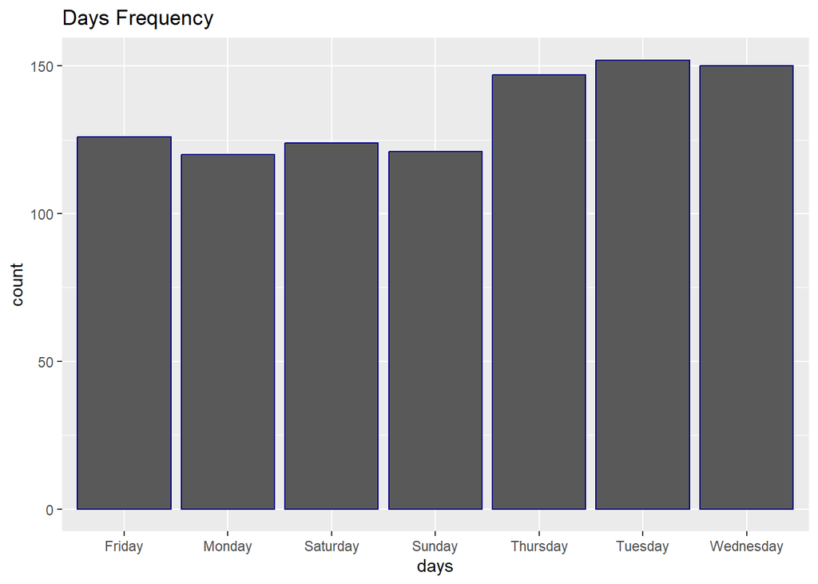

[output not shown]

```r
ggplot(data = daily_activity, aes(x = days)) +
  geom_bar(color = 'darkblue') +
  labs(title = "Days Frequency")
```

```r
sedentary_min <- mean(daily_activity$sedentary_minutes)
lightly_active_min <- mean(daily_activity$lightly_active_minutes)
fairly_active_min <- mean(daily_activity$fairly_active_minutes)
very_active_min <- mean(daily_activity$very_active_minutes)
```

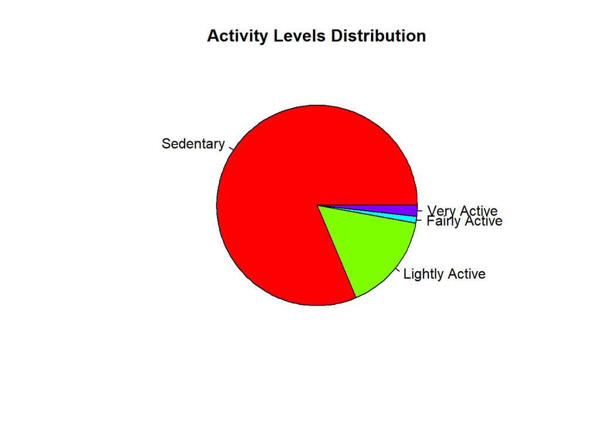

```r
pie(
  c(sedentary_min, lightly_active_min, fairly_active_min, very_active_min),
  labels = c("Sedentary", "Lightly Active", "Fairly Active", "Very Active"),
  main = "Activity Levels Distribution",
  col = rainbow(4)  # Adds colors to the slices
)
```

## Step 6: Act

### Recommendations:

Based on the analysis, here are the actionable strategies for Bellabeat:

#### 1. **Promote Bellabeat as a Multipurpose Device:**

- Educate users that Bellabeat products are not just for exercise but can be used for daily activities like work, commuting, and general health tracking.
- Highlight the benefits of using Bellabeat products to improve overall health and fitness.

#### 2. **Introduce Rewards and Reminders:**

- Add features in the Bellabeat app to:
- Reward users for achieving daily goals like 7,500 steps or 8 hours of sleep.
- Send reminders to users who are falling behind on their goals.
  - Rewards could include virtual medals, leaderboards, or discounts.

#### 3. **Gather More Data:**

- Conduct a new survey targeting women to collect up-to-date health and habit data.
- Use social media platforms like Instagram, Facebook, and Twitter to reach a wider audience.

#### 4. **Membership Discounts for Activity:**

- Introduce a feature where users can earn discounts on Bellabeat membership by burning calories.
- This encourages users to stay active while increasing Bellabeat’s customer base.

## Conclusion

By analyzing fitness tracker data, we identified trends and behaviors that can guide Bellabeat’s marketing strategies. These recommendations aim to attract a broader audience, improve user engagement, and promote healthier lifestyles for women.

## Next Steps

1. Implement app updates based on recommendations.
2. Design and conduct the new survey.
3. Track the impact of these changes on user behavior and sales.